# REGRESSION MODEL

SAIFUDDIN MOHD

December 24, 2015

## Executive Summary

This document contains an analysis of the mtcars dataset included in R. In it, I seek to answer the following questions:

1. Is an automatic or manual transmission better for mpg?
2. Quantify the MPG difference between automatic and manual transmissions.

In the present project, we have attempted to answer the question of whether manual or automatic transmission is a better choice for efficient fuel usage in cars. The data used for this analysis come from the 1974 Motor Trend US Magazine. We have performed hypothesis testing and fitted linear models to establish and quantify the relationship between MPG and type of transmission. In short, it is easy to see that cars that manual cars get better MPG. Understanding why though is a more complicated matter. I believe the weight of the car is really the most important factor and through using linear models, predict that the true difference in MPG between an automatic and manual car, if all else in the car were the same, is somewhere between 3 and 7 mpg.

## MPG vs. Transmission Type

An initial boxplot showing mpg for both automatic and manual cars (fig 1) shows that manual cars have much better MPG on average. Specifically, our observed difference is 7.2 MPG. This is helpful initial information, but this observed difference can only tell us so much. The transmission system of a car effects things like car weight, rear axle ratio, and number of forward gears. These things have effects on engine size, horsepower, and so on. To figure out which variables are really causing this noticable change in MPG, let’s examine what variables are correlated with MPG and transmission type and then fit a linear model using that information.

## Characteristics of Automatic Cars

Something we can to do explore the relationship of these variables is simply to look at correlation values (fig 2). Values closer to -1 and 1 indicate a stronger relationship. We can then plot some of the things that are different between automatic and manual cars (fig 3). Automatic cars are heavier, have larger engines, more horespower, and weaker rear axle ratios. In addition, the strongest variable associated with mpg is car weight (fig 4), so it’s possible that automatic cars simply weigh more, thus requiring larger engines and getting lower mpg. It’s also interesting to note that weight has a greater effect on manual cars than automatic cars. Linear models are ill-equiped to describe causation, but let’s see if we can find a good linear model that takes into account these variable relationships.

## Fitting the Best Linear Model

Now, we will consider three linear models that describe the relationship between transmission and fuel efficiency. The models are as follows:

1. MPG predicted by transmission type only.
2. MPG predicted by all variables available.
3. MPG predicted by transmission, weight, and their continuous interaction.

### Interpreting Coefficients

Here’s what we can conclude from interpreting the coefficients of our models.

#### Model 1

This model (fig 5) shows that the average MPG for automatic cars is 17.1 and that the average MPG for manual cars is 17.1 + 7.2, or 24.3. This is essentially the imperical average that we previously observed, but this model now allows us to create a confidence interval. Under this model, we can say with 95% confidence that the true difference in MPG between an automatic and manual car lies within the interval (3.7, 10.8). This is done by taking our 7.2 and adding/subtracting two times the standard error.

#### Model 2

This model (fig 6) takes into account all varaibles available. Under this model, our estimate for the difference in MPG between a manual and automatic car is much lower at 2.6 and our confidence interval is (-1.4, 6.6) I believe this lower value is caused by two things. Firstly, the model takes into account counfounding variables that really may be having a greater impact on on MPG, thus taking emphasis off the transmission variable. Second, the model introduces greater variance in our regression variables due to the larger number of predictor variables included.

#### Model 3

This final model (fig 7) seeks to describe how weight affects mpg for both automatic and manual cars. This model shows us that automatic cars have a -3.8 decrease in MPG for every 1000lb increase in car weight, whereas manual cars have a -3.8 + (-5.3), or -9.1 decrease in MPG for every 1000lb increase in car weight. In other words, manual cars handle car weight increase poorly, but since manual cars tend to be lighter they still come out ahead in MPG.

### Diagnostics

Lastly, let’s briefly look at some residual plots and variance diagnostics of our models to help diagnose their efficacy. We’ll specifically look at models 1 and 2 since those try and quantify the MPG difference by transmission type. We don’t see much variation in these residual plots (fig 8), which is a good thing. In model 1, we can see that there is less variation around the lower mpg, which would correspond to automatic cars and greater variance around the higher mpg, which would correspond to manual cars. This is interesting, but not necessarily a sign of bad model fit. In model 2, there isn’t much of a pattern evident.

Let’s also look at our $R^2$ values for models 1 and 2. This is a way of describing how much of the total variance in MPG was explained by our model. For model 1, the $R^2$ value was 0.36 and for model 2 it was 0.88. Thus, it’s clear that our second model explains much more of the variation than model 1.

## Conclusion

In conclusion, it is clear that manual cars get better gas mileage, and I believe that car weight is the biggest reason why. In addition, if I were to quantify this change in MPG, I would do so by taking the overlapping section of my confidence intervals and giving a final estimate of (3.7, 6.6).

# Appendix

## Figure 1

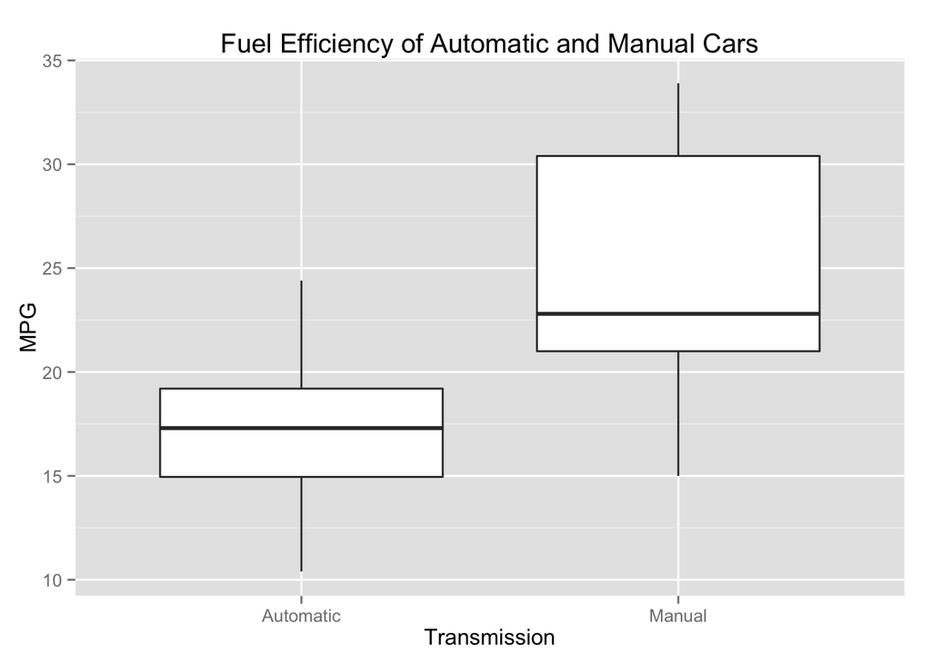

## Figure 2 (Variables correlated with mpg and transmission)

|  | Transmission | MPG |
| --- | --- | --- |
| mpg | 0.5998324 | 1.0000000 |
| cyl | -0.5226070 | -0.8521620 |
| disp | -0.5912270 | -0.8475514 |
| hp | -0.2432043 | -0.7761684 |
| drat | 0.7127111 | 0.6811719 |
| wt | -0.6924953 | -0.8676594 |
| qsec | -0.2298609 | 0.4186840 |
| vs | 0.1683451 | 0.6640389 |
| am | 1.0000000 | 0.5998324 |
| gear | 0.7940588 | 0.4802848 |
| carb | 0.0575344 | -0.5509251 |

## Figure 3

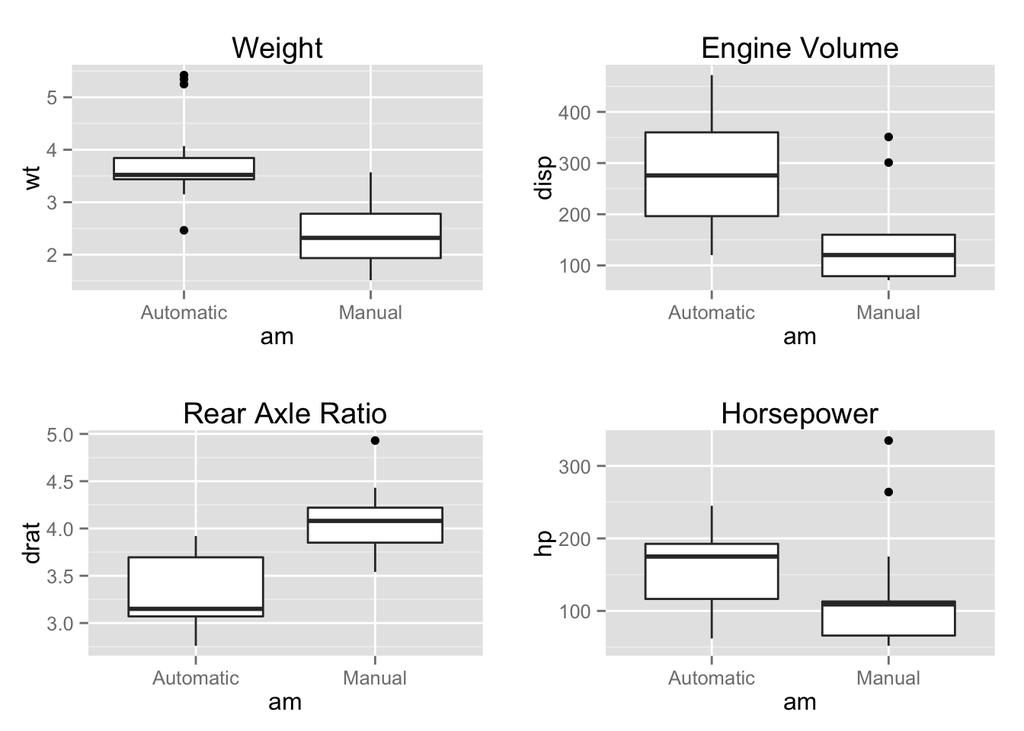

## Figure 4

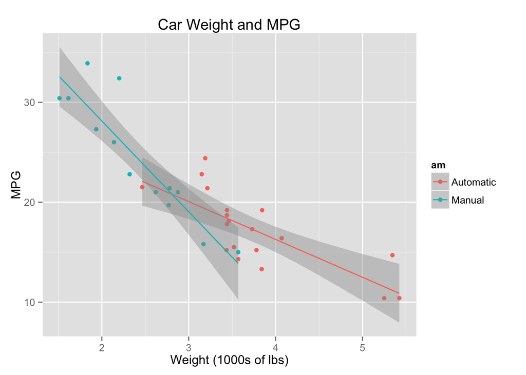

## Figure 5 (Model 1)

```r
fit1 <- lm(mpg ~ am, data = mtcars)
fit2 <- lm(mpg ~ ., data = mtcars)
fit3 <- lm(mpg ~ am + wt + am * wt, data = mtcars)
```

|  | Estimate | Std. Error | t value | Pr(>\|t\|) |
| --- | --- | --- | --- | --- |
| (Intercept) | 17.147368 | 1.124602 | 15.247492 | 0.000000 |
| amManual | 7.244939 | 1.764422 | 4.106127 | 0.000285 |

## Figure 6 (Model 2)

|  | Estimate | Std. Error | t value | Pr(>\|t\|) |
| --- | --- | --- | --- | --- |
| (Intercept) | 17.8198433 | 16.3060232 | 1.0928381 | 0.2874542 |
| cyl6 | -1.6603067 | 2.2622966 | -0.7339032 | 0.4715245 |
| cyl8 | 1.6374398 | 4.3157345 | 0.3794116 | 0.7083808 |
| disp | 0.0139124 | 0.0174018 | 0.7994830 | 0.4334036 |
| hp | -0.0461284 | 0.0271202 | -1.7008869 | 0.1044619 |
| drat | 0.0263503 | 1.6764895 | 0.0157175 | 0.9876155 |
| wt | -3.8062476 | 1.8466431 | -2.0611712 | 0.0525285 |
| qsec | 0.6469571 | 0.7219502 | 0.8961242 | 0.3808461 |
| vsStraight engine | 1.7473869 | 2.2726721 | 0.7688689 | 0.4509559 |
| amManual | 2.6172655 | 2.0047494 | 1.3055325 | 0.2065309 |
| gear | 0.7640292 | 1.4566802 | 0.5245003 | 0.6056959 |
| carb | 0.5093512 | 0.9424418 | 0.5404590 | 0.5948487 |

## Figure 7 (Model 3)

|  | Estimate | Std. Error | t value | Pr(>\|t\|) |
| --- | --- | --- | --- | --- |
| (Intercept) | 31.416055 | 3.0201093 | 10.402291 | 0.0000000 |
| amManual | 14.878422 | 4.2640422 | 3.489276 | 0.0016210 |
| wt | -3.785907 | 0.7856478 | -4.818836 | 0.0000455 |
| amManual:wt | -5.298361 | 1.4446993 | -3.667449 | 0.0010171 |

## Figure 8 (Residual Plots)

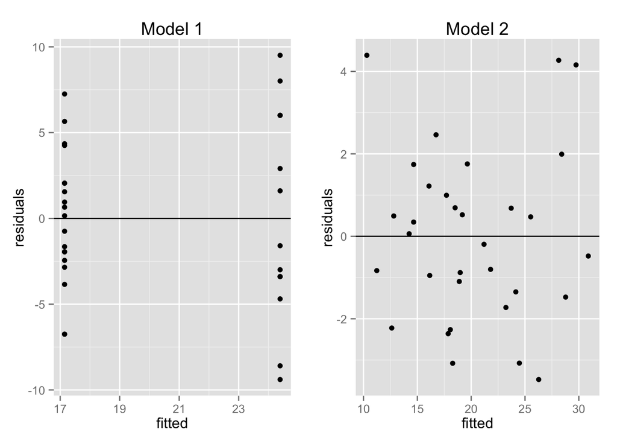